# Fitting Step-Selection Functions with `amt`

Johannes Signer

2024-11-25

## About

This vignette briefly introduces how one can fit a Step-Selection Function (SSF) with the `amt` package. We will be using the example data of one red deer from northern Germany and one covariate: a forest cover map. For a more through discussion see also Fieberg et al. 2021[^1] and supplement B.

## Getting the data ready

First we load the required libraries and the relocation data (called `deer`)

```r
library(lubridate)
library(amt)
data("deer")
deer
```

```
## # A tibble: 826 × 4
##          x_       y_ t_                  burst_
##  *    <dbl>    <dbl> <dttm>               <dbl>
##  1 4314068. 3445807. 2008-03-30 00:01:47      1
##  2 4314053. 3445768. 2008-03-30 06:00:54      1
##  3 4314105. 3445859. 2008-03-30 12:01:47      1
##  4 4314044. 3445785. 2008-03-30 18:01:24      1
##  5 4313015. 3445858. 2008-03-31 00:01:23      1
##  6 4312860. 3445857. 2008-03-31 06:01:45      1
##  7 4312854. 3445856. 2008-03-31 12:01:11      1
##  8 4312858. 3445858. 2008-03-31 18:01:55      1
##  9 4312745. 3445862. 2008-04-01 00:01:24      1
## 10 4312651. 3446024. 2008-04-01 06:00:54      1
## # ℹ 816 more rows
```

In order to continue, we need a regular sampling rate. To check the current sampling rate, we use `summarize_sampling_rate`:

```r
summarize_sampling_rate(deer)
```

```
## # A tibble: 1 × 9
##     min    q1 median  mean    q3   max    sd     n unit
##   <dbl> <dbl>  <dbl> <dbl> <dbl> <dbl> <dbl> <int> <chr>
## 1  5.96  6.00   6.01  11.5  6.02 3924.  137.   825 hour
```

The median sampling rate is 6h, which is what we aimed for.

Next, we have to get the environmental covariates. A forest layer is included in the package. Note, that this a regular `SpatRast`.

```r
sh_forest <- get_sh_forest()
sh_forest
```

```
## class       : SpatRaster
## dimensions  : 720, 751, 1  (nrow, ncol, nlyr)
## resolution  : 25, 25  (x, y)
## extent      : 4304725, 4323500, 3437725, 3455725  (xmin, xmax, ymin, ymax)
## coord. ref. : +proj=laea +lat_0=52 +lon_0=10 +x_0=4321000 +y_0=3210000 +ellps=GRS80 +towgs84=0,0,0,0,0,0,0 +units=m +no_defs
## source(s)   : memory
## name        : forest
## min value   :      0
## max value   :      1
```

## Prepare Data for SSF

### Steps

Before fitting a SSF we have to do some data preparation. First, we change from a point representation to a step representation, using the function `steps_by_burst`, which in contrast to the `steps` function accounts for bursts.

```r
ssf1 <- deer |> steps_by_burst()
```

### Control/random steps

The generic function `random_steps` provides a methods for a `track_xy*`, where each observed step is paired with `n_control` control steps (i.e., steps that share the same starting location but have different turn angles and step lengths). The distributions for drawing step lengths and turning angles are usually obtained by fitting known parametric distribution to the observed step length and turn angles.

The function `random_steps` has seven arguments. For most use cases the defaults are just fine, but there might situation where the user wants to adjust some of the arguments. The arguments are:

#### The default situation

In most situations the following code snippet should work[^4].

```r
ssf1 <- ssf1 |> random_steps(n_control = 15)
```

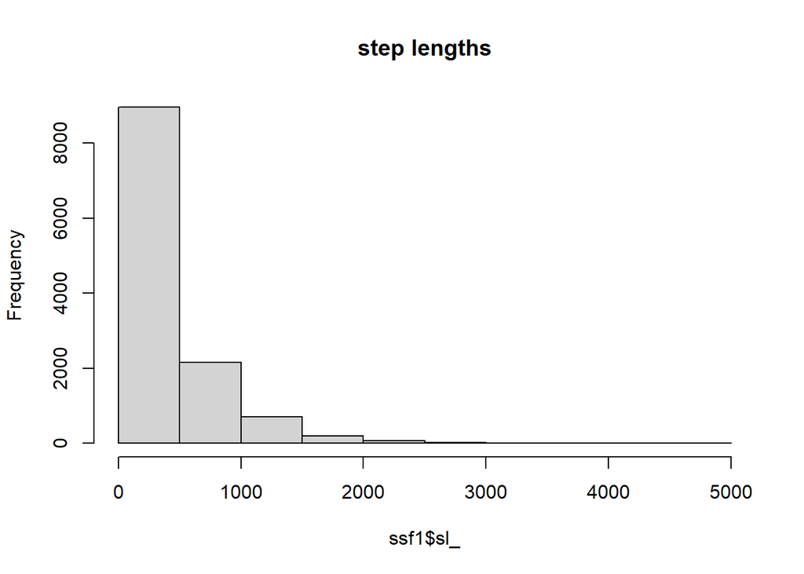

```r
hist(ssf1$sl_,main='step lengths')
```

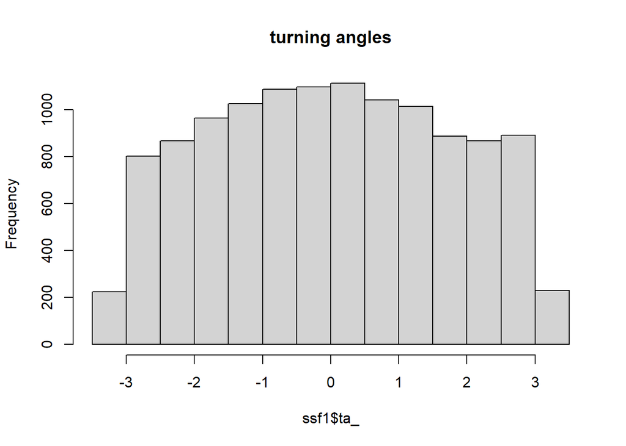

```r
hist(ssf1$ta_,main='turning angles')
```

### Extract covariates

As a last step, we have to extract the covariates at the end point of each step. We can do this with `extract_covariates`.

```r
ssf1 <- ssf1 |> extract_covariates(sh_forest)
```

```r
ssf1 <- ssf1 |>
  mutate(forest = factor(forest, levels = 1:0, labels = c("forest", "non-forest")),
         cos_ta = cos(ta_),
        log_sl = log(sl_))
```

## Fitting SSF

Now all pieces are there to fit a SSF. We will use `fit_clogit`, which is a wrapper around `survival::clogit`.

```r
m0 <- ssf1 |> fit_clogit(case_ ~ forest + strata(step_id_))
m1 <- ssf1 |> fit_clogit(case_ ~ forest + forest:cos_ta + forest:log_sl +  strata(step_id_))
summary(m0)
```

```
## Call:
## coxph(formula = Surv(rep(1, 12096L), case_) ~ forest + strata(step_id_),
##     data = data, method = "exact")
##
##   n= 12096, number of events= 756
##
##                     coef exp(coef) se(coef)      z Pr(>|z|)
## forestnon-forest -0.5145    0.5978   0.1088 -4.727 2.28e-06 ***
## ---
## Signif. codes:  0 '***' 0.001 '**' 0.01 '*' 0.05 '.' 0.1 ' ' 1
##
##                  exp(coef) exp(-coef) lower .95 upper .95
## forestnon-forest    0.5978      1.673     0.483      0.74
##
## Concordance= 0.529  (se = 0.007 )
## Likelihood ratio test= 21.65  on 1 df,   p=3e-06
## Wald test            = 22.34  on 1 df,   p=2e-06
## Score (logrank) test = 22.44  on 1 df,   p=2e-06
```

```r
summary(m1)
```

```
## Call:
## coxph(formula = Surv(rep(1, 12096L), case_) ~ forest + forest:cos_ta +
##     forest:log_sl + strata(step_id_), data = data, method = "exact")
##
##   n= 12096, number of events= 756
##
##                             coef exp(coef) se(coef)      z Pr(>|z|)
## forestnon-forest         0.84859   2.33635  0.32724  2.593 0.009510 **
## forestforest:cos_ta     -0.11644   0.89008  0.09693 -1.201 0.229614
## forestnon-forest:cos_ta -0.43141   0.64959  0.06505 -6.632  3.3e-11 ***
## forestforest:log_sl      0.17369   1.18969  0.04956  3.505 0.000457 ***
## forestnon-forest:log_sl -0.08338   0.92000  0.02856 -2.919 0.003512 **
## ---
## Signif. codes:  0 '***' 0.001 '**' 0.01 '*' 0.05 '.' 0.1 ' ' 1
##
##                         exp(coef) exp(-coef) lower .95 upper .95
## forestnon-forest           2.3363     0.4280    1.2302    4.4370
## forestforest:cos_ta        0.8901     1.1235    0.7361    1.0763
## forestnon-forest:cos_ta    0.6496     1.5394    0.5718    0.7379
## forestforest:log_sl        1.1897     0.8406    1.0796    1.3111
## forestnon-forest:log_sl    0.9200     1.0870    0.8699    0.9730
##
## Concordance= 0.609  (se = 0.013 )
## Likelihood ratio test= 90.02  on 5 df,   p=<2e-16
## Wald test            = 87.6  on 5 df,   p=<2e-16
## Score (logrank) test = 89.63  on 5 df,   p=<2e-16
```

```r
AIC(m0)
```

```
## [1] 4172.509
```

```r
AIC(m1)
```

```
## [1] 4112.137
```

```r
summary(m1)
```

```
## Call:
## coxph(formula = Surv(rep(1, 12096L), case_) ~ forest + forest:cos_ta +
##     forest:log_sl + strata(step_id_), data = data, method = "exact")
##
##   n= 12096, number of events= 756
##
##                             coef exp(coef) se(coef)      z Pr(>|z|)
## forestnon-forest         0.84859   2.33635  0.32724  2.593 0.009510 **
## forestforest:cos_ta     -0.11644   0.89008  0.09693 -1.201 0.229614
## forestnon-forest:cos_ta -0.43141   0.64959  0.06505 -6.632  3.3e-11 ***
## forestforest:log_sl      0.17369   1.18969  0.04956  3.505 0.000457 ***
## forestnon-forest:log_sl -0.08338   0.92000  0.02856 -2.919 0.003512 **
## ---
## Signif. codes:  0 '***' 0.001 '**' 0.01 '*' 0.05 '.' 0.1 ' ' 1
##
##                         exp(coef) exp(-coef) lower .95 upper .95
## forestnon-forest           2.3363     0.4280    1.2302    4.4370
## forestforest:cos_ta        0.8901     1.1235    0.7361    1.0763
## forestnon-forest:cos_ta    0.6496     1.5394    0.5718    0.7379
## forestforest:log_sl        1.1897     0.8406    1.0796    1.3111
## forestnon-forest:log_sl    0.9200     1.0870    0.8699    0.9730
##
## Concordance= 0.609  (se = 0.013 )
## Likelihood ratio test= 90.02  on 5 df,   p=<2e-16
## Wald test            = 87.6  on 5 df,   p=<2e-16
## Score (logrank) test = 89.63  on 5 df,   p=<2e-16
```

[^1]: https://besjournals.onlinelibrary.wiley.com/doi/full/10.1111/1365-2656.13441
[^2]: See also `?fit_distr`.
[^3]: Note, this possible because of the [Glivenko-Cantelli theorem](https://en.wikipedia.org/wiki/Glivenko%E2%80%93Cantelli_theorem) and works as long as the sample from the original distribution (the sample you provide here) is large enough.
[^4]: And how it was implemented in `amt` up to version 0.0.6. This **should** be backward compatible and not break existing code.